# Red Wine Analysis by Mark MacArdle

# Multivariate Analysis

### Talk about some of the relationships you observed in this part of the

investigation. Were there features that strengthened each other in terms of  
looking at your feature(s) of interest?

Alcohol and volatile.acidity still showed the strongest relationship with quality.

### Were there any interesting or surprising interactions between features?

Bound.sulfur.dioxide and sulphates have an ineresting non linear relationship with quality. Quality=5 having a much higher mean level of bound SO2.

Salt and sugar don’t have much realationship with quality.

### OPTIONAL: Did you create any models with your dataset? Discuss the

strengths and limitations of your model.

A model was created but it’s best R-squared value was only 0.361 so it was not very good. This may be because it is a linear model and the relationships between the variables and quality are not all linear, such as quality and bound SO2. Other modelling methods that can take into account non linear relationships may give a better result.

# Final Plots and Summary

### Plot One

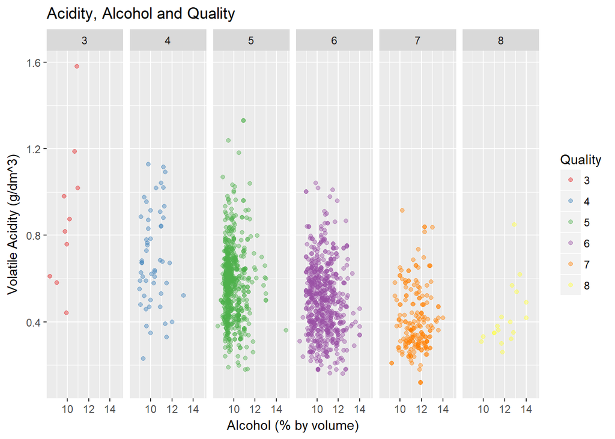

### Description One

From quality=5 to 8 it can be seen how the mean alcohol is increasing and the mean volatile acidity decreasing. These are the strongest correlating variables to quality.

### Plot Two

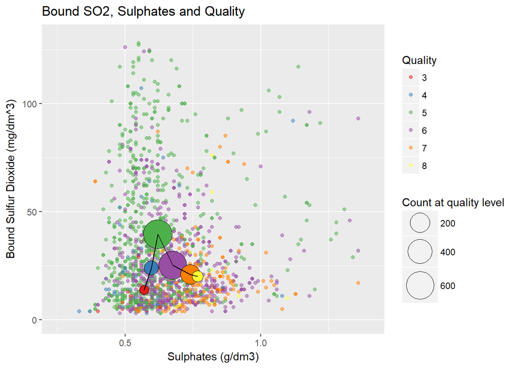

### Description Two

The line between the mean points shows an interesting relationship. Bound SO2 and quality don’t have a linear relationship. There’s a peak at quality=5. This shows that increasing bound SO2 is initally benificial but then a hindrence to reaching high quality levels. Whereas increasing sulphates has a more linear relationship with higher levels correlating with higher quality scores.

### Plot Three

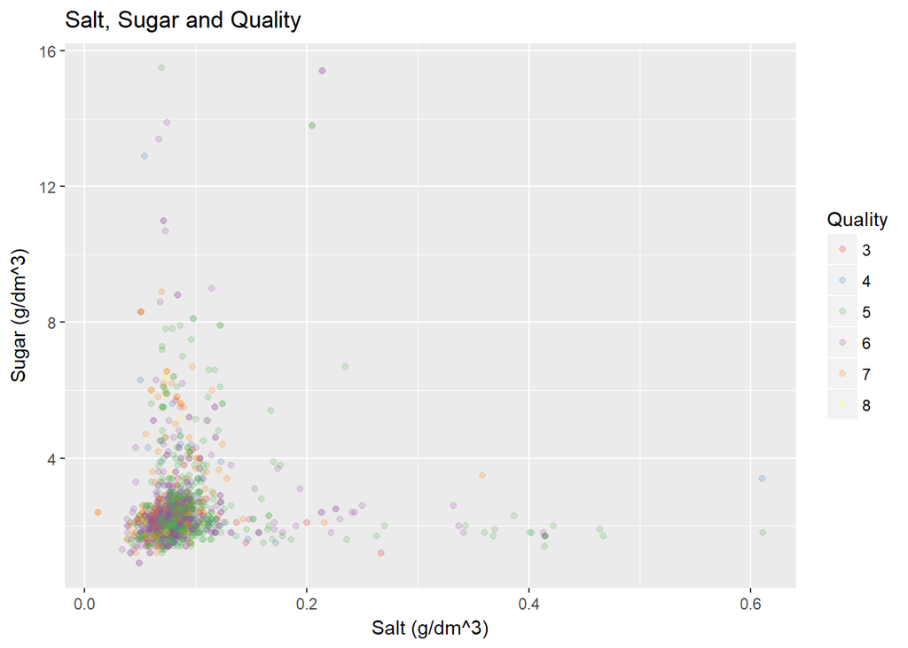

### Description Three

It can be seen that quality=5 are the most common high salt wine, qualit=6 are most common high sugar wines but the vast majority of wines are clustered with both low salt and sugar.

# Reflection

It was interesting that alcohol percentage had the strongest correlation to quality of the variables. The strenght of a wine is rarely discussed as key component of how good it will taste. The fact it had the strongest correlation may point to a basic fact that connoisseurs see as beneath them: that people often just like alcohol.

I stuggled to create an new variables that had a strong correlation to quality. Bound.sulfur.dioxide was the best I did and it did have some limited use.

I was surprised that the acidity variables didn’t have much correlation to the pH. It seemed natural to think that they woudl have been what was driving the pH.

I was also surprised that salt and sugar didn’t have a correlation to quality or each other as they are so commonly used to improve the taste in other drinks.

Future work could be done on investigating non linear modelling methods that could be used to make better predicitons of quality from the input variables.